# Stats_Inference_Course_Project

LI CHENYANG

December 25, 2015

## 1. Overview: In a few (2-3) sentences explain what is going to be reported on.

- In this section I will investigate the exponential distribution in R and compare it with the Central Limit Theorem

## 2. Simulations: Include English explanations of the simulations you ran, with the accompanying R code. Your explanations should make clear what the R code accomplishes.

(Majority of the codes referred from Prof Brian Caffo’s lecture notes. Therefore all credit goes to him. )

The goal is to demonstrate *Central Limit Therom* with random variables generated by exponential distribution

- First, create a group of 40 random variables x 1000 random variable, with each row represent one observation of the 40 variables.

```r
nosim <-  1000
All_observ <- matrix(rexp(40000, rate = 0.2), nosim)
```

- Next creat a function to calculate and normalize all the means from one row of observation

```r
cfunc <- function(x, n) sqrt(n) * (mean(x) - 5) / 5
```

- Next create a dataframe by applying function over each row in the All_observ matrix

```r
n_size = 40
final_form <- data.frame(samples = apply(X = All_observ, MARGIN = 1, FUN = cfunc, n_size))
```

## 3. Sample Mean versus Theoretical Mean: Include figures with titles. In the figures, highlight the means you are comparing. Include text that explains the figures and what is shown on them, and provides appropriate numbers.

- According to central limit therom, the theoretical mean for the distribution of sample mean, after proper normalization, should be 0.
- Similarly, the theoretical variance after normalization, should be 1.
- Below is the plot of the distribution of mean of 40 exponential variable.

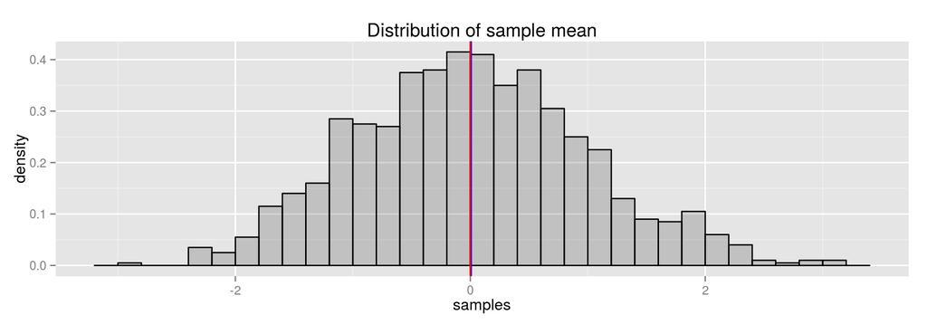

```r
mean(final_form$samples)
```

```
## [1] 0.006811327
```

which is fairly close to the theoretic mean.

- By observation, we can see that the sample distribution is centered comfortably around the population mean.
- Next, we look at sample variance to further validate central limit theorem.

## 4. Sample Variance versus Theoretical Variance: Include figures (output from R) with titles. Highlight the variances you are comparing. Include text that explains your understanding of the differences of the variances.

- Variability of the graph will affect the width of the graph.
- The higher the variance, the narrower the graph will be.
- Therefore, we can draw in this case a standard normal distribution and try to compare the width with that of the sample distribution

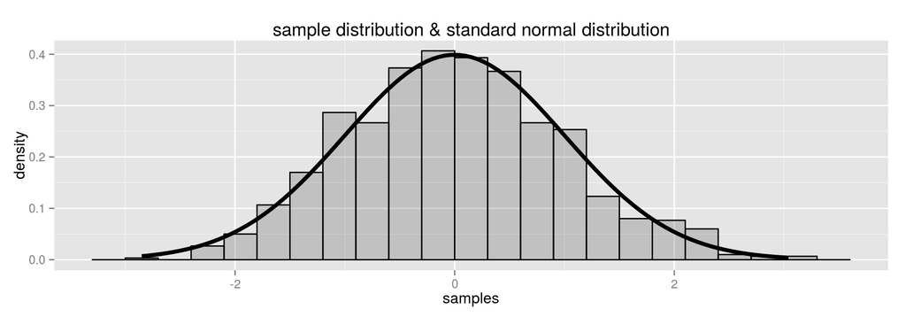

- The black curve represent standard normal distribution.
- As we can see there is almost no difference in width between these two distributions.
- To further prove the point, we calculat the sample variance.

```r
var(final_form$samples)
```

```
## [1] 0.97069
```

- the sample variance is very very close to 1.
- Therefore we can safely conclude that in this case, Central Limit Theorem is validated.

## 5. Distribution: Via figures and text, explain how one can tell the distribution is approximately normal.

- We can simply tell that the distribution is roughly normal, just by looking at the plot below

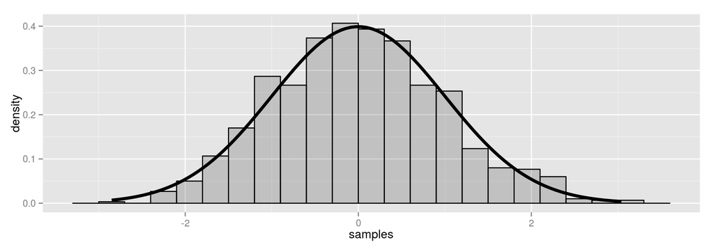

- To show how different it would be if it is just random expontial distribution samples, without taking averages. We construct the following plot:

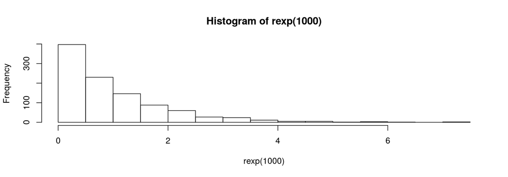

- We can tell by the graph above that the plot is no way gaussian.